# IA para Científicos Sociales

Sesión 5.2: Detección de sesgo y regulación

Danilo Freire

danilofreire@gmail.com

Departament of Data and Decision Sciences  
Emory University

# De los tipos de sesgo a la acción

## Repaso de la sesión anterior

**Tipos de sesgo que vimos:**

- Histórico: discriminación codificada
- Representación: grupos ausentes
- Medición: proxies problemáticos
- Agregación: un modelo para todos
- Evaluación: benchmarks sesgados
- Despliegue: contexto equivocado

El sesgo puede entrar en cualquier etapa y se amplifica con bucles de retroalimentación.

**Hoy: ¿qué hacemos al respecto?**

- ¿Cómo medimos la equidad?
- ¿Cómo detectamos el sesgo?
- ¿Cómo mitigamos el sesgo?
- ¿Qué dice el teorema de imposibilidad?
- ¿Cómo se regula la IA?
- ¿El sesgo es solucionable?

# Métricas de equidad

## ¿Cómo medimos si un modelo es justo?

**Métricas basadas en grupos:**

Comparan el rendimiento del modelo entre grupos (por ejemplo, hombres vs. mujeres, o por etnicidad).

| Métrica | Pregunta que responde |
| --- | --- |
| **Paridad demográfica** | ¿Los grupos reciben resultados positivos a tasas similares? |
| **Igualdad de oportunidades** | ¿Los verdaderos positivos tienen la misma tasa entre grupos? |
| **Odds equalizados** | ¿FPR y TPR son iguales entre grupos? |
| **Calibración** | ¿Una predicción de 70% significa lo mismo para todos los grupos? |
| **Predictive parity** | ¿El valor predictivo positivo es igual entre grupos? |

[figure not shown]

Métricas de equidad

Fuente: [Google AI](https://developers.google.com/machine-learning/crash-course/fairness/video-lecture)

Cada métrica captura una noción diferente de “justo”.

## Paridad demográfica

**Definición:**

> La proporción de resultados positivos debe ser igual entre grupos.

$$P(\hat{Y} = 1 | A = a) = P(\hat{Y} = 1 | A = b)$$

**Ejemplo: contratación**

- Si el 30% de los hombres son contratados, el 30% de las mujeres también deben serlo
- No importa si los candidatos son diferentes

**Ventaja:**

- Fácil de medir y comunicar
- Garantiza representación

**Desventaja:**

- Ignora si los grupos tienen diferentes tasas base
- Puede requerir contratar candidatos menos cualificados
- No garantiza que los individuos sean tratados justamente

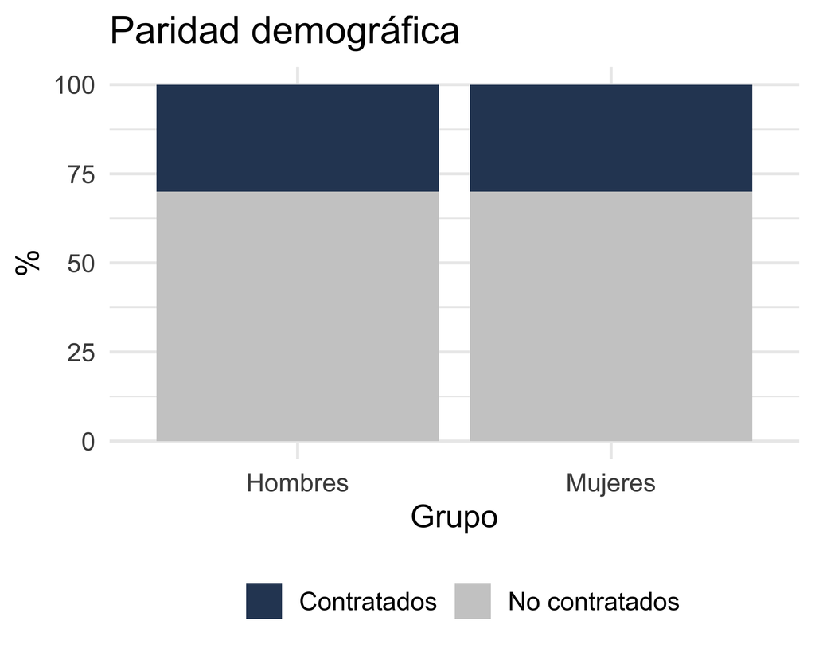

Misma tasa de contratación = paridad demográfica.

## Igualdad de oportunidades

**Definición:**

> Entre quienes merecen un resultado positivo, la tasa de acierto debe ser igual entre grupos.

$$P(\hat{Y} = 1 | Y = 1, A = a) = P(\hat{Y} = 1 | Y = 1, A = b)$$

**Ejemplo: préstamos**

- Entre las personas que pagarían el préstamo, ambos grupos deben tener la misma probabilidad de ser aprobados
- Mide si el modelo deja pasar a los “buenos” por igual

**Ventaja:**

- Más intuitiva que paridad demográfica
- No requiere igualar tasas de aprobación

**Desventaja:**

- Requiere conocer el “verdadero” resultado (Y)
- Solo mira falsos negativos, ignora falsos positivos

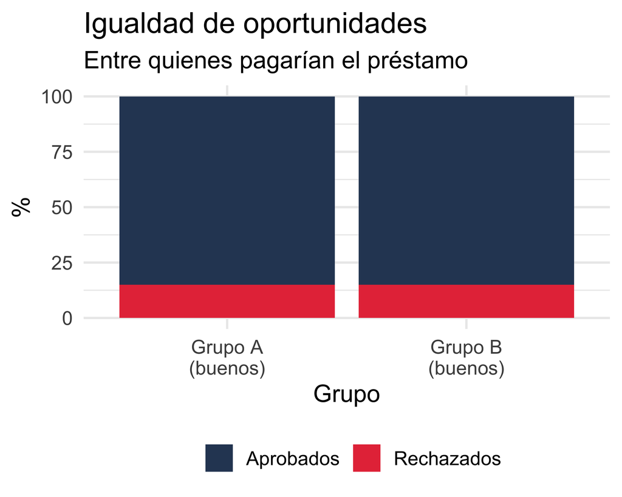

Mismo TPR entre grupos.

## Calibración

**Definición:**

> Una predicción de X% debe significar lo mismo para todos los grupos.

$$P(Y = 1 | \hat{Y} = p, A = a) = P(Y = 1 | \hat{Y} = p, A = b) = p$$

**Ejemplo: riesgo de reincidencia**

- Si el modelo dice “70% de probabilidad de reincidencia”, entonces el 70% de las personas con esa puntuación deberían reincidir
- Esto debe cumplirse tanto para blancos como para negros

**Ventaja:**

- Las predicciones son interpretables
- Permite comparar individuos de diferentes grupos

**Desventaja:**

- No garantiza igualdad en tasas de error
- Un modelo puede estar calibrado pero ser injusto en otros sentidos

[figure not shown]

Calibración

Fuente: [ProPublica](https://www.propublica.org/article/machine-bias-risk-assessments-in-criminal-sentencing)

COMPAS estaba calibrado pero tenía diferentes tasas de falsos positivos por raza.

# El teorema de imposibilidad

## No se puede tener todo

**Tres criterios de equidad (simplificados):**

1. **Calibración**: entre quienes reciben la misma puntuación, los resultados deben ser similares entre grupos
2. **Igualdad de falsos positivos**: los grupos deben tener tasas iguales de ser señalados erróneamente
3. **Igualdad de falsos negativos**: los grupos deben tener tasas iguales de ser ignorados erróneamente

**El teorema de imposibilidad** ([Chouldechova, 2017](https://doi.org/10.1089/big.2016.0047); [Kleinberg, Mullainathan y Raghavan, 2016](https://arxiv.org/abs/1609.05807)):

> Si las tasas base difieren entre grupos, no se pueden satisfacer los tres criterios simultáneamente.

**En simple**: si el Grupo A reincide al 40% y el Grupo B al 20%, hay que elegir qué tipo de error igualar.

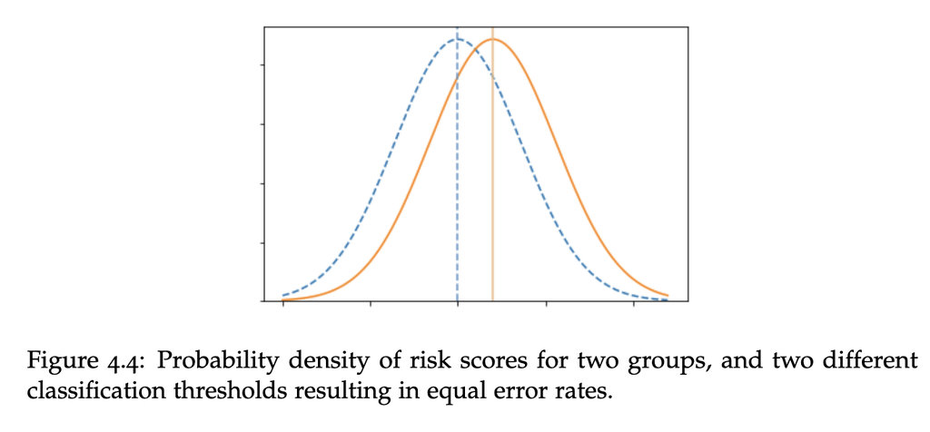

Teorema de imposibilidad

Fuente: [Fairness and Machine Learning Book](https://fairmlbook.org/)

No existe una solución matemáticamente “justa”. Ningún algoritmo puede decidir qué errores importan más.

## ¿Quién define “justo”?

**Lo que cuenta como justo depende de lo que valoramos:**

| Definición | Prioriza | Desventaja |
| --- | --- | --- |
| **Igual trato** | Consistencia | Ignora el contexto |
| **Igualdad de resultados** | Equidad | Puede requerir trato diferenciado |
| **Igual tasa de error** | Paridad entre grupos | Puede sacrificar precisión |
| **Calibración** | Precisión individual | Oculta disparidades |

- No existe un valor por defecto neutral
- Quien elige la definición de equidad determina quién se beneficia
- Decir “solo usamos los datos” es en sí mismo una elección
- Esta es una pregunta política y moral, no técnica

## Actividad: el dilema del préstamo

**Están diseñando un algoritmo de aprobación de préstamos**

**Los datos muestran:**

- Grupo A: 80% paga los préstamos
- Grupo B: 60% paga los préstamos (debido a desventaja económica histórica)

**Deben elegir UNO de estos enfoques:**

1. **Mismo umbral para todos**: 70% de probabilidad de pago = aprobado
   - Resultado: más rechazos del Grupo B
2. **Misma tasa de aprobación**: ajustar umbrales para que ambos grupos tengan 50% de aprobación
   - Resultado: más impagos, mayor riesgo
3. **Misma tasa de rechazo injusto**: asegurar que el mismo % de buenos pagadores sea rechazado en ambos grupos
   - Resultado: diferentes tasas de aprobación

**Preguntas para discutir:**

- ¿Cuál enfoque es “más justo”?
- ¿Quién se beneficia y quién se perjudica con cada uno?
- ¿Cambiaría su respuesta si la menor tasa del Grupo B se debe a discriminación (no a capacidad)?
- ¿Debería el algoritmo intentar corregir la injusticia histórica, o solo no perpetuarla?

**Debatan en grupos de 3-4 personas (10 min) y presenten su decisión.**

# Detección y mitigación

## ¿Cómo detectamos el sesgo?

**Paso 1: Definir los grupos protegidos**

- ¿Qué grupos queremos proteger?
- Género, etnicidad, edad, discapacidad, ubicación…
- A veces la variable no está en los datos (proxies)

**Paso 2: Calcular métricas por grupo**

- Tasa de predicción positiva
- Tasa de verdaderos positivos (TPR)
- Tasa de falsos positivos (FPR)
- Valor predictivo positivo (PPV)

**Paso 3: Comparar entre grupos**

- ¿Las diferencias son significativas?
- ¿Superan un umbral aceptable?
- Regla del 80%: si un grupo tiene menos del 80% de la tasa del otro, hay disparidad

**Herramientas disponibles:**

| Herramienta | Lenguaje | Descripción |
| --- | --- | --- |
| [AI Fairness 360](https://aif360.res.ibm.com/) | Python | IBM, 70+ métricas |
| [Fairlearn](https://fairlearn.org/) | Python | Microsoft |
| [fairmodels](https://fairmodels.drwhy.ai/) | R | Integra con tidymodels |
| [What-If Tool](https://pair-code.github.io/what-if-tool/) | Web | Google, visual |
| [Aequitas](http://aequitas.dssg.io/) | Python | U. Chicago |

En el laboratorio usaremos fairmodels para auditar un modelo de clasificación.

## Estrategias de mitigación

**Pre-procesamiento**

Modificar los datos antes de entrenar.

- Rebalancear grupos
- Eliminar variables sensibles
- Transformar datos para reducir correlación con atributo protegido

**Ejemplo:** reponderar muestras para que grupos estén representados igualmente.

**Ventaja:** modelo agnóstico

**Desventaja:** puede perder información útil

**In-procesamiento**

Modificar el algoritmo durante el entrenamiento.

- Agregar restricciones de equidad a la función de pérdida
- Regularización adversarial
- Aprendizaje justo (fair learning)

**Ejemplo:** penalizar predicciones que violen paridad demográfica.

**Ventaja:** solución integrada

**Desventaja:** más complejo, específico del algoritmo

**Post-procesamiento**

Modificar las predicciones después de entrenar.

- Ajustar umbrales por grupo
- Rechazar predicciones con alta incertidumbre
- Calibración por grupo

**Ejemplo:** usar umbral de 0.6 para Grupo A y 0.5 para Grupo B.

**Ventaja:** modelo agnóstico, fácil de implementar

**Desventaja:** puede parecer discriminación inversa

Ninguna técnica es perfecta. La mitigación implica trade-offs.

## El caso COMPAS

**¿Qué es COMPAS?**

- Correctional Offender Management Profiling for Alternative Sanctions
- Sistema de scoring de riesgo de reincidencia usado en EE.UU.
- Usado para decisiones de fianza, sentencia, libertad condicional

**El análisis de ProPublica (2016):**

- COMPAS tenía tasas de falsos positivos desiguales:
  - Negros: 44,9% señalados como alto riesgo pero no reincidieron
  - Blancos: 23,5% señalados como alto riesgo pero no reincidieron
- ProPublica concluyó: el sistema es racialmente sesgado

**La respuesta de Northpointe (creadores de COMPAS):**

- COMPAS está calibrado: una puntuación de 7 significa lo mismo para blancos y negros
- Si las tasas base de reincidencia difieren, no se pueden igualar FPR y calibración a la vez
- El teorema de imposibilidad en acción

[figure not shown]

COMPAS

Fuente: [ProPublica](https://www.propublica.org/article/machine-bias-risk-assessments-in-criminal-sentencing)

**¿Quién tiene razón?**

Ambos. El debate no es sobre hechos sino sobre valores: ¿qué tipo de error importa más?

# Regulación de la IA

## EU AI Act (2024)

**Primera ley integral sobre IA en el mundo**

Clasifica sistemas por nivel de riesgo:

| Nivel | Ejemplos | Requisitos |
| --- | --- | --- |
| Inaceptable | Scoring social masivo, manipulación subliminal, vigilancia biométrica en tiempo real | Prohibido |
| Alto riesgo | Salud, justicia, empleo, migración, educación, crédito | Evaluación de conformidad, auditoría, registro |
| Riesgo limitado | Chatbots, deepfakes | Transparencia (informar que es IA) |
| Riesgo mínimo | Filtros de spam, videojuegos | Sin restricciones |

**Multas:** hasta 35 millones de euros o 7% de la facturación global

**Aplicación:** gradual desde 2024 hasta 2027

[figure not shown]

EU AI Act

Fuente: [European Commission](https://digital-strategy.ec.europa.eu/en/policies/regulatory-framework-ai)

**Implicaciones para investigadores:**

- Sistemas de IA para investigación están exentos
- Pero si el sistema se despliega, aplica la regulación

## Regulación en Estados Unidos

**Sin ley federal integral**

- Enfoque sectorial y descentralizado
- Agencias regulan sus dominios: FDA (salud), FTC (consumidores), EEOC (empleo)

**Regulación estatal:**

- California: SB 1047 (2024) propuso regulación de modelos grandes, vetada por el gobernador
- Nueva York: Local Law 144 (2023) requiere auditoría de IA en contratación
- Colorado: ley de gobernanza de IA (2024)

**Orden ejecutiva de Biden (octubre 2023):**

- Requisitos de seguridad para modelos grandes
- Estándares de watermarking para contenido generado por IA
- Revocada por la administración Trump en enero de 2025

[figure not shown]

Regulación de IA en EE.UU.

Fuente: [Brookings](https://www.brookings.edu/articles/the-current-state-of-ai-regulation-in-the-us/)

**Situación actual:**

- Sin marco federal unificado
- Fragmentación regulatoria
- Autorregulación de la industria

## Regulación en América Latina

**Uruguay**

- Ley 18.331 de Protección de Datos Personales
- Estrategia Nacional de IA (2019)
- URCDP como órgano de control
- Referente regional en gobierno digital
- Proyecto de ley específica de IA en discusión

**Brasil**

- LGPD (2018) para protección de datos
- PL 2338/2023: proyecto de ley de IA aprobado por el Senado en diciembre de 2024
- Ahora en la Cámara de Diputados
- Inspirado en el EU AI Act con adaptaciones locales

**Chile**

- Primera Política Nacional de IA (2021) en la región
- Proyecto de ley de neuroderechos (pionero global)
- Protección de datos mentales y libertad cognitiva

**Colombia**

- Marco ético de IA (2019)
- Sandbox regulatorio para innovación
- Énfasis en ética y derechos humanos

**Argentina**

- Plan Nacional de IA (2019)
- Ley de datos personales en actualización
- Debate sobre regulación específica

**Desafíos comunes en la región:**

- Marcos regulatorios en construcción
- Brecha entre legislación y aplicación
- Dependencia de infraestructura extranjera
- Necesidad de capacidad técnica en agencias reguladoras
- Pocos recursos para auditoría y fiscalización

Uruguay está bien posicionado, pero falta ley específica de IA.

## Autorregulación y estándares

**Estándares técnicos:**

- ISO/IEC 42001: sistema de gestión de IA
- IEEE P7000: diseño ético de sistemas
- NIST AI RMF: marco de gestión de riesgos

**Principios de la industria:**

- Google: AI Principles (2018)
- Microsoft: Responsible AI Standard
- IBM: Principles for Trust and Transparency
- OpenAI: preparedness framework
- Anthropic: responsible scaling policy

**Iniciativas académicas:**

- Montreal Declaration (2018)
- Asilomar AI Principles (2017)
- OECD AI Principles (2019)

**Críticas a la autorregulación:**

- Sin poder de aplicación
- Conflicto de intereses: quien desarrolla, audita
- Principios vagos y no vinculantes
- Ética-washing: apariencia sin sustancia
- Las empresas abandonan compromisos cuando son inconvenientes
  - Google: despido del equipo de IA ética (2020)
  - OpenAI: restructuración y salidas (2024)

**Consenso emergente:**

La autorregulación no es suficiente. Se necesita regulación vinculante con supervisión externa.

# Perspectivas

## ¿Es solucionable el sesgo en la IA?

**Los optimistas**

- El sesgo de la IA es un problema técnico con soluciones técnicas
- Mejores datos, mejores algoritmos, mejores auditorías
- La IA podría ser menos sesgada que los humanos:
  - Los humanos son inconsistentes; la IA es consistente
  - Las decisiones de la IA se pueden auditar; las intuiciones humanas no
- Los datasets están mejorando, la regulación avanza

> “Un algoritmo sesgado se puede reentrenar. Un gerente de contratación sesgado es más difícil de arreglar.”

**Los escépticos**

- El sesgo de la IA refleja problemas sociales que no se solucionan con código
- Hablar de “IA justa” distrae de las causas raíz
- ¿Quién define la equidad? Generalmente quienes ya tienen poder
- La IA oculta la responsabilidad humana
- Algunas decisiones no deberían automatizarse

> “No se puede arreglar un mercado inmobiliario discriminatorio ajustando un modelo de scoring crediticio.”

**¿Dónde se ubican ustedes?**

## ¿Qué pueden hacer los investigadores?

**En su propia investigación:**

- Documentar las limitaciones del modelo
- Reportar métricas por subgrupos
- Transparentar los datos y el código
- Considerar quién puede ser afectado
- Evitar claims exagerados de equidad

**En la sociedad:**

- Auditar sistemas existentes
- Comunicar hallazgos al público
- Participar en debates de política pública
- Formar a la próxima generación

**Preguntas para cada proyecto:**

1. ¿Qué daños podría causar este sistema?
2. ¿Quiénes son los grupos afectados?
3. ¿Cómo mediría si el sistema es justo?
4. ¿Qué variables podrían ser proxies de atributos sensibles?
5. ¿Quién decidió la definición de éxito?
6. ¿Hay supervisión humana de las decisiones?
7. ¿Existe un mecanismo de apelación?
8. ¿Cómo se actualizará el sistema?

La ética no es un paso final; es parte del diseño desde el inicio.

## Resumen de la sesión

**Métricas de equidad:**

- Paridad demográfica: misma tasa de positivos
- Igualdad de oportunidades: mismo TPR
- Calibración: predicciones significan lo mismo
- El teorema de imposibilidad: no se pueden tener todas

**Detección y mitigación:**

- Pre-procesamiento, in-procesamiento, post-procesamiento
- Herramientas: AI Fairness 360, Fairlearn, fairmodels
- El caso COMPAS: calibrado pero con FPR desiguales

**Regulación:**

- EU AI Act: clasificación por riesgo
- EE.UU.: fragmentado, sin ley federal
- América Latina: Uruguay bien posicionado, leyes en construcción
- Autorregulación no es suficiente

**Para reflexionar:**

- El sesgo es parcialmente técnico, parcialmente social
- La equidad es una elección de valores, no solo de algoritmos
- Los investigadores tienen responsabilidad

En el laboratorio: auditoría práctica de sesgo con fairmodels.

# Nos vemos en el laboratorio